# What is Indie?

### A data exploration into r/indieheads' Essentials List

## Introduction

Everyone has heard of indie. But does anyone actually KNOW what it is? Everytime I hear someone tell me that they're "into indie stuff", I do not gain any new information other than they probably think they're hip. Oh well, I know I can't confidently say what it is, but I do know that I love it, whatever it is. So let's take a crack at understanding it!

The word indie is the abbreviation of "independent", and similarly indie music originally was meant to describe music that were produced independent of commercial or major record labels which became . Over time, however, it became clear that the music that associated "indie" is no longer tied to the size of enterprise or mode of distribution--it has developed its own sound. What sound exactly? If you look at the [Spotify indie playlist](https://open.spotify.com/playlist/37i9dQZF1DX2Nc3B70tvx0?si=f180f37d84a94971), you'd say it's somewhere between the psych rock of Tame Impala, the bedroom pop of Rex Orange County, and the cloud rap of Yung Lean. Yeah, not very helpful. Algorithmic driven playlist curation is extremely good at discovering streaming patterns but can heavily feature recency bias and also be disconnected from creative influences as well as the communities and culture that forms around music scenes.

When I first began a serious exploration of indie, what helped me a lot in discovering the "cannons" of indie was the [essentials chart](https://i.imgur.com/QNI5g9D.jpg) on r/indieheads. This is a list put together by community members who have a strong interest in indie music, who most likely all had their own niche and favorites but came together to vote on the most crucial pieces of records that define the genre. The chart features one album per artist other than the exception Radiohead and Pavement, and it features music from 80s to the 2000s. It purposefully avoids music after 2010s to only include albums that have passed the test of time. My goal is to analyze the albums featured on the chart to figure out what is it that makes them "indie", and to do so I will be use Spotify API and statistical analysis tools.

## Getting Started

For this tutorial, you would need to install spotipy, pandas, numpy, statsmodels, matplotlib, seaborn, scipy, networkx, and pyvis, and then import all of below.

```python
import spotipy
import pandas as pd
import random
import string
import math
import numpy as np
import matplotlib.pyplot as plt
import seaborn
from spotipy.oauth2 import SpotifyClientCredentials
from scipy.stats import zscore
from scipy.stats import ttest_ind
from scipy.stats import norm
import networkx as nx
from pyvis.network import Network
import statsmodels.api as sm
```

The first step in our process would be to set up authorization to make calls with Spotify. To do this we would need to first create a Spotify account (or use your existing one), and then create an app at the [developer's dashboard] (https://developer.spotify.com/dashboard/applications). Once we create an app and enter into the page, write down the Client ID and Client secret.

```python
cid = YOUR_CLIENT_ID_HERE
secret = YOUR_CLIENT_SECRET_HERE
```

There are multiple ways to gain permissions to make calls with (Spotify Web API)[https://developer.spotify.com/documentation/web-api/reference/#/]. Since we are not using user specific data, we can just use our app's client credentials to request the access token, which would use to request stuff from the API through the spotipy.Spotify object.

```python
#Authentication - without user
client_credentials_manager = SpotifyClientCredentials(client_id=cid, client_secret=secret, requests_timeout=10)
sp = spotipy.Spotify(client_credentials_manager = client_credentials_manager)
```

So here I manually copy-pasted the list from the [reddit page](https://www.reddit.com/r/indieheads/wiki/essentials/) into a text document called 'indieheads essentials.txt'. The next step would be to parse this file in order to store them in tuples for easier manipulation.

Note that this data is quite sloppy and I had to mess with it manually a bit to tidy it up. Due to Spotify not being able to find some of albums through how it is listed in the reddit page, I edited some entries in the text document.

For example:

"The Stones Roses - The Stone Roses" -> "The Stone Roses - The Stone Roses" (they made a typo)

"Brian Eno & David Byrne - My Life in the Bush of Ghosts" - > "Brian Eno - My Life in the Bush of Ghosts" (not gonna change my code structure to process multiple artists for one outlier, I got rid of the less popular artist, but it should not alter our result significantly.)

"Songs: Ohia - The Magnolia Electric Co." -> "Songs: Ohia - Magnolia Electric Co." (They wrote an extra "the" for some reasons)

"The Olivia Tremor Control - Music from the Unrealized Film Script: Dusk at Cubist Castle" -> The Olivia Tremor Control - Dusk at Cubist Castle" (I believe spotify shortened this title from the original release title?)

"Bright Eyes - I'm Wide Awake,It's Morning" -> "Bright Eyes - Im Wide Awake,Its Morning" (The apostraphes mess with the spotify searches for some reasons)

This is not an exhaustive list, it should contain an example of every type of error within the raw dataset.

```python
essentials = []
with open('indieheads essentials.txt') as f:
    lines = f.readlines()
    for line in lines:
        if '-' in line:
            album = line.split('-')
            album[0] = album[0].strip()
            album[1] = album[1].strip()
            essentials.append(album)
```

So Spotify Web API basically works by having separate endpoints for tracks, albums, and artists each, and they are accessed by URIs. Of course, we don't have it yet, we only have album and artist names, so to gain the URI and other useful JSONs from the API we would need to use their search request. Here, I attempt to search for each artist and then its correlating album

```python
artists = []
albums = []
for album in essentials:
    #Inputing search query to find artist
    artist_search = sp.search(q = 'artist:' + album[0], limit = 1, type = 'artist')['artists']['items']
    if len(artist_search) > 0:
        #Inputing search query to find album
        album_search = sp.search(q = 'artist:' + album[0] + ' album:' + album[1], limit = 1, type = 'album')["albums"]["items"]
        if len(album_search) > 0:
            artists.append(artist_search[0])
            albums.append(album_search[0])
        else:
            print("Cannot find album: " + album[0] + "-" + album[1])
    else:
        print("Cannot find artist: " + album[0] + "-" + album[1])
```

```
Cannot find album: Joanna Newsom-Ys
Cannot find album: Bonnie 'Prince' Billy-I See a Darkness
Cannot find album: Big Black-Songs About Fucking
Cannot find album: Minor Threat-Complete Discography
Cannot find album: Spacemen 3-The Perfect Prescription
```

I manually checked on spotify and it turns out these albums are just no on it, but we are still left with 135 data points, good enough!

## Genre Breakdown

I've always been skeptical under "indie" as on its own a standalone genre, as it just doesn't feel like it describes anything concrete about the sonic qualities and it's way too broad. Another way to think about indie would be theorize it as a descriptor or pseudo genre that other genres can be applied to not be subsumed as a subgenre under.

Spotify Web API can present genre tags for any given artist that they generate using a mix of listen pattern and audio attributes. Spotify also has no remorse naming new genres their algorithm discovered in listening pattern so the genre will understandbly be a little disconnected how people usually think about genres at time.

In this step, I iterate through all of the artists and albums to extract relevant information to be stored in data frame, and I calculate the relative frequency of each genre tag.

```python
indie_df = pd.DataFrame()
for i in range(len(artists)):
    #Extracting relevant information from artist JSON
    artist_name = artists[i]["name"]
    artist_uri = artists[i]["uri"]
    artist_genres = artists[i]["genres"]
    artist_popularity = artists[i]["popularity"]
    #Extracting relevant information from album JSON
    album_name = albums[i]["name"]
    album_uri = albums[i]["uri"]
    album_date = albums[i]["release_date"]
    album_track_num = albums[i]["total_tracks"]
    #Creating corresponding row and adding to main dataframe
    new_df = pd.DataFrame({"artist_name":artist_name, "artist_uri":artist_uri, "artist_genres":artist_genres,
                     "artist_popularity":artist_popularity, "album_name": album_name, "album_uri": album_uri,
                     "album_date": album_date, "album_track_num": album_track_num})
    indie_df = pd.concat([indie_df, new_df], ignore_index = True)
```

```python
indie_genre_freq = indie_df.artist_genres.value_counts()/len(indie_df.artist_name.unique())
```

```python
indie_genre_freq
```

```
alternative rock     0.603053
indie rock           0.480916
rock                 0.312977
art rock             0.251908
modern rock          0.244275
                       ...
austindie            0.007634
portland indie       0.007634
albuquerque indie    0.007634
stoner rock          0.007634
pub rock             0.007634
Name: artist_genres, Length: 209, dtype: float64
```

There are already interesting data here, such as the fact that more than half of the artists featured on the essentials list is tagged with alternative rock, even higher than the proportion of artists tagged with indie rock! I think this isn't too surprising, considering that indeed indie in its early days were developed out of the alternative rock scenes, and across 80s and 90s, you can label many indie rock or indie pop artists of the time as alt-rock as well.

However, this data isn't too helpful though when it composes of 209 genre tags... We could just arbitraily make a cut off point, but we can do better with significance testing!

To do this, we will produce a control sample in order to better contextualize data of the indie albums. There is a problem though, since Spotify doesn't have any built in feature for random sampling of its databass, we would have to make a DIY approach to generate our random sample. I use the fact that Spotify API's search request takes in the % character and combine it with the selection of a random character to genrate random search query. There is still the problem that Spotify's search would return the artists with higher popularity on top, so I also randomized the offset parameter in the search call.

```python
random_df = pd.DataFrame()
for i in range(300):
    a = sp.search(q = "%" + random.choice(string.ascii_letters+string.digits) + "%", limit = 1, type = 'artist', offset = random.randrange(1000))["artists"]["items"]
    while(len(a) == 0):
        a = sp.search(q = "%" + random.choice(string.ascii_lowercase) + "%", type = 'artist', offset = random.randrange(1000))["artists"]["items"]
    a = a[0]
    artist_name = a["name"]
    artist_uri = a["uri"]
    artist_genres = a["genres"]
    new_df = pd.DataFrame({"artist_name":artist_name, "artist_uri":artist_uri, "artist_genres":artist_genres})
    random_df = pd.concat([random_df, new_df], ignore_index = True)
```

With the random sample of all artists on Spotify, we can then use their genre tags to produce the control relative frequency of each genre on Spotify.

```python
random_genre_freq = random_df.artist_genres.value_counts()/len(random_df.artist_name.unique())
```

Since we have two sample populations and for each there exist a set of relative frequencies, we can move forward in plugging in each variable to conduct a [two-proportion z-test](https://www.statisticshowto.com/probability-and-statistics/hypothesis-testing/z-test/) for each genre that was present amongst the indie artists. I choose the alpha level of 0.1% for the entirety of this tutorial.

Using this, we can find the list of genres that are statistically significant in their increased proportion in indie music compared to music released on Spotify in general.

```python
significant_genres = {}
for genre in indie_genre_freq.index:
    p1 = 0
    if genre in random_genre_freq:
        p1 = random_genre_freq[genre]
    p2 = indie_genre_freq[genre]
    n1 = len(random_df.artist_name.unique())
    n2 = len(indie_df.artist_name.unique())
    p = (p2 * n2 + p1 * n1)/(n1+n2)
    z = (p2 - p1)/math.sqrt(p*(1-p)*(1/n1+1/n2))
    #Using alpha = 0.001
    if  norm.sf(abs(z)) < 0.001:
        significant_genres[genre] = indie_genre_freq[genre]
```

Here I chose to visualize the genre breakdown of genres that are found to be tagged amongst indie artists significantly higher than average. It's important to understand how we should interpret this-it's not that if we pick up a alternative rock records, there's a 60% chance it would be indie. What this does say is that an alternative rock record would be much more likely to be indie compared to a record not tagged with it, and also that indie fans tend to listen to artists tagged with these genres more than the average music fan.

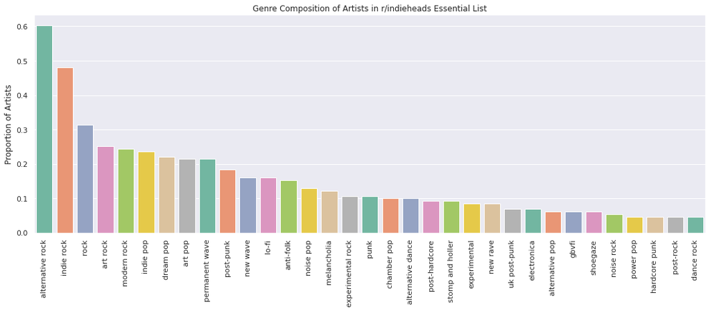

```python
keys = list(significant_genres.keys())
vals = [significant_genres[k] for k in keys]
seaborn.set(rc={'figure.figsize':(18,6)})
seaborn.barplot(x=keys, y=vals, palette=seaborn.color_palette("Set2"))
plt.title('Genre Composition of Artists in r/indieheads Essential List')
plt.xlabel('')
plt.ylabel('Proportion of Artists')
plt.xticks(rotation=90)
plt.show()
```

## Audio Features

It's interesting for sure to see what genres are associated with "indieness", but that still doesn't say a lot concrete about what indie sounds like, especially since spotify genre classification are so unconventional.

One way we can get closer to how indie songs actually *sound* like is through the audio features for each song provided by Spotify Web API. Beyond obvious attributes such as duration, tempo, and loudness, it also analyzes scores for danceability, energy, valence (meaning positivity/negativity), acousticness (the chance that the song is acoustic) and instrumentalness (the chance that the song is fully instrumental and vocalless). Read more about them [here](https://developer.spotify.com/documentation/web-api/reference/#/operations/get-several-audio-features). Again, we iterate through URIs and make calls to the spotify API to gather data regarding the audio feature of each track, and store them into a new Data Frame specifically for tracks.

```python
indie_song_df = pd.DataFrame()
for album_uri in indie_df.album_uri.unique():
    #Find all tracks in album
    tracks = sp.album_tracks(album_uri)["items"]
    album = indie_df.loc[indie_df["album_uri"] == album_uri, "album_name"].iloc[0]
    #Extract release year of album, parse out non-year data
    year =  indie_df.loc[indie_df["album_uri"] == album_uri, "album_date"].iloc[0][:4]
    for track in tracks:
        name = track["name"]
        artist = track["artists"][0]["name"]
        artist_uri = track["artists"][0]["uri"]
        track_features = sp.audio_features(track["id"])[0]
        #Some tracks do not have audio features information, check to avoid error
        if track_features != None:
            #Storing track audio features
            uri = track_features["uri"]
            duration =track_features["duration_ms"]
            danceability = track_features["danceability"]
            energy = track_features["energy"]
            loudness = track_features["loudness"]
            acousticness = track_features["acousticness"]
            instrumentalness = track_features["instrumentalness"]
            valence = track_features["valence"]
            tempo = track_features["tempo"]
            new_df = pd.DataFrame([{"album": album, "name": name, "artist":artist, "artist_uri":artist_uri, "uri":uri,
                                    "duration":duration,"danceability": danceability, "energy": energy, "loudness":loudness,
                                    "acousticness": acousticness, "instrumentalness":instrumentalness, "valence":valence,
                                    "tempo":tempo, "year":year}])
            indie_song_df = pd.concat([indie_song_df, new_df], ignore_index = True)
```

Using these data, we can find the averages for each of the features extracted from all the songs from the indie albums. Note that I did not choose to take the mean acousticness and instrumentalness, this is because they are measures of confidence in prediction rathere than a "score" like the others. I believe they are better interpreted as a measures of what proportion of indie songs Spotify believes is more likely than not to be "acoustic" or "instrumental"

```python
avg_indie_duration = indie_song_df.duration.mean()
avg_indie_danceability = indie_song_df.danceability.mean()
avg_indie_energy = indie_song_df.energy.mean()
avg_indie_loudness = indie_song_df.loudness.mean()
avg_indie_valence = indie_song_df.valence.mean()
avg_indie_tempo = indie_song_df.tempo.mean()

indie_acoustic = len(indie_song_df[indie_song_df.acousticness > 0.5])/len(indie_song_df)
indie_instrumental = len(indie_song_df[indie_song_df.instrumentalness > 0.5])/len(indie_song_df)
```

```python
print("Duration: ", avg_indie_duration, "\n",
      "Danceability: ", avg_indie_danceability, "\n",
     "Energy: ", avg_indie_energy, "\n",
     "Loudness: ", avg_indie_loudness, "\n",
     "Valence: ", avg_indie_valence, "\n",
     "Tempo: ", avg_indie_tempo, "\n",
     "Portion of Acoustic Songs", indie_acoustic, "\n"
     "Portion of Instrumental Songs: ", indie_instrumental)
```

```
Duration:  237502.80451513597
 Danceability:  0.45613950743971166
 Energy:  0.6311446695741416
 Loudness:  -9.679092868137516
 Valence:  0.4308981015905586
 Tempo:  123.41170497691134
 Portion of Acoustic Songs 0.26475115443817343
Portion of Instrumental Songs:  0.3124679322729605
```

The duration of 237502 ms roughly breaks down to 4 minutes, the mean tempo sits at around 123 beats per minutes, ~26.5% of indie songs are predicted to be acoustic and ~31.2% of indie songs are predicted to be instrumental only. This is about all we can find out from the raw break down of these audio features. Scores like danceability, energy, and valence are Spotify constructs that do not translate directly to reality, and they would only be meaningful to us relative to other scores. Moreover, we cannot tell if any of these data points are actually a particular characterstics of indie (either more or less than average), or whether they are simply characterstics of music in general.

Based on my understanding of indie, I would guess that they should be longer, less danceable, and lower in energy than the average music, as indie is typically associated with "chillness" or contemplative listening. It might also be quieter, as a lot of the songs featured are older, and music have gone louder over the years due to the loudness war. I would guess it to be lower in valence and more negative as well, since a lot of indie music I know are associated with sadness. Also, I would guess that indie music would more acoustic songs due to its association with rustic DIY and instrumental songs as well.

However, I wouldn't know if any of my hypothesis were true without testing it against the control population. Here, I used the random artist sample from earlier and generate a random song sample by taking the top tracks from each artist.

```python
random_song_df = pd.DataFrame()
for artist_uri in random_df.artist_uri.unique():
    tracks = sp.artist_top_tracks(artist_uri)["tracks"]
    for track in tracks:
        name = track["name"]
        artist = track["artists"][0]["name"]
        artist_uri = track["artists"][0]["uri"]
        track_features = sp.audio_features(track["id"])[0]
        if track_features != None:
            uri = track_features["uri"]
            duration =track_features["duration_ms"]
            danceability = track_features["danceability"]
            energy = track_features["energy"]
            loudness = track_features["loudness"]
            acousticness = track_features["acousticness"]
            instrumentalness = track_features["instrumentalness"]
            valence = track_features["valence"]
            tempo = track_features["tempo"]
            new_df = pd.DataFrame([{"name": name, "artist":artist, "artist_uri":artist_uri, "uri":uri,
                                    "duration":duration,"danceability": danceability, "energy": energy, "loudness":loudness,
                                    "acousticness": acousticness, "instrumentalness":instrumentalness, "valence":valence,
                                    "tempo":tempo}])
            random_song_df = pd.concat([random_song_df, new_df], ignore_index = True)
```

```python
avg_duration = random_song_df.duration.mean()
avg_danceability = random_song_df.danceability.mean()
avg_energy = random_song_df.energy.mean()
avg_loudness = random_song_df.loudness.mean()
acoustic = len(random_song_df[random_song_df.acousticness > 0.5])/len(indie_song_df)
instrumental = len(random_song_df[random_song_df.instrumentalness > 0.5])/len(indie_song_df)
avg_valence = random_song_df.valence.mean()
avg_tempo = random_song_df.tempo.mean()
```

```python
print("Duration: ", avg_duration, "\n",
      "Danceability: ", avg_danceability, "\n",
     "Energy: ", avg_energy, "\n",
     "Loudness: ", avg_loudness, "\n",
     "Valence: ", avg_valence, "\n",
     "Tempo: ", avg_tempo, "\n",
     "Portion of Acoustic Songs", acoustic, "\n"
     "Portion of Instrumental Songs: ", instrumental)
```

```
Duration:  221345.67164179104
 Danceability:  0.597575350520127
 Energy:  0.5877457982813201
 Loudness:  -9.004583446404332
 Valence:  0.5015034147444601
 Tempo:  119.60405246494796
 Portion of Acoustic Songs 0.3304258594150847
Portion of Instrumental Songs:  0.16880451513596717
```

Without further analysis, nothing immediately jumps out yet other than the fact that the acousticness of the random sample torns out to be higher than indie music.

With a control sample also gained, we can now conduct significance testing on audio features. This time, since we are comparing two sample means, we will be using [scipy](https://docs.scipy.org/doc/scipy/reference/generated/scipy.stats.ttest_ind.html) to conduct t-tests.

```python
#Duration T-test
ttest_ind(random_song_df.duration, indie_song_df.duration)
```

```
Ttest_indResult(statistic=-3.3132575827854254, pvalue=0.0009300480515389352)
```

```python
#Danceability T-test
ttest_ind(random_song_df.danceability, indie_song_df.danceability)
```

```
Ttest_indResult(statistic=25.414014294813757, pvalue=1.4446715069925896e-132)
```

```python
#Energy T-test
ttest_ind(random_song_df.energy, indie_song_df.energy)
```

```
Ttest_indResult(statistic=-5.594209190504214, pvalue=2.358747362208231e-08)
```

```python
#Loudness T-test
ttest_ind(random_song_df.loudness, indie_song_df.loudness)
```

```
Ttest_indResult(statistic=4.1370258608858155, pvalue=3.587922737300241e-05)
```

```python
#Valence T-test
ttest_ind(random_song_df.valence, indie_song_df.valence)
```

```
Ttest_indResult(statistic=8.833579707149406, pvalue=1.46889969521402e-18)
```

```python
#Tempo T-test
ttest_ind(random_song_df.tempo, indie_song_df.tempo)
```

```
Ttest_indResult(statistic=-4.072737499112816, pvalue=4.7328955561873496e-05)
```

Again mainting an alpha of 0.001, it seems that every indie audio feature differ significantly from control song features after conducting t-test. Moreover, it seems that danceability is the feature tha differs from control the most by far with the p-value of 1.44e-132, and I would propose that it might be the best predictor we have so far in distinguishing indie music from other types of music.

For acousticness and instrumentallness, I again return to two-proportion z tests as I treat them as binarily describing how many songs are more likely to acoustic or instrumental.

```python
#Acoustic Two Proportion Z Test
p1 = acoustic
p2 = indie_acoustic
n1 = len(random_song_df)
n2 = len(indie_song_df)
p = (p2 * n2 + p1 * n1)/(n1+n2)
z = (p2 - p1)/math.sqrt(p*(1-p)*(1/n1+1/n2))
norm.sf(abs(z))
```

```
1.9742844449649935e-06
```

```python
#Instrumental Two Proportion Z Test
p1 = instrumental
p2 = indie_instrumental
n1 = len(random_song_df)
n2 = len(indie_song_df)
p = (p2 * n2 + p1 * n1)/(n1+n2)
z = (p2 - p1)/math.sqrt(p*(1-p)*(1/n1+1/n2))
norm.sf(abs(z))
```

```
6.6152907733867725e-28
```

Now, we can begin our data visualization of the distributions of audio features.

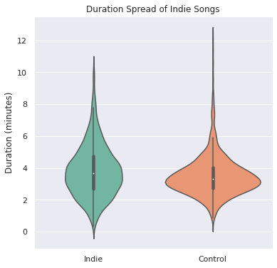

```python
seaborn.set(rc={'figure.figsize':(6,6)})
#Removing outliers (three standard deviations away) in order to produce more intelligible plot.
indie_duration_no = indie_song_df[np.abs(zscore(indie_song_df.duration)) < 3]["duration"]/1000/60
random_duration_no = random_song_df[np.abs(zscore(random_song_df.duration)) < 3]["duration"]/1000/60
seaborn.violinplot(data=[indie_duration_no, random_duration_no], palette=seaborn.color_palette("Set2")[:2])
plt.title('Duration Spread of Indie Songs')
plt.xlabel('')
plt.xticks(range(2), ['Indie', 'Control'])
plt.ylabel('Duration (minutes)')
plt.show()
```

Duration data has plenty of outliers, and generally it's seen that both sample skews right. This is because there generally much more space for song to get longer than shorter. However, it should be noted that this plot would look considerably different with the inclusion outliers, and indie music is somewhat known for its unusually lenghty songs. So, just for fun, let's find out what are the longest songs as included in the r/indieheads essentials chart.

```python
i = 1
for j, row in indie_song_df[np.abs(zscore(indie_song_df.duration)) > 3].sort_values(by=["duration"], ascending=False).iterrows():
    ms = row["duration"]
    seconds = int(ms/1000)
    minutes = int(seconds/60)
    seconds = seconds - minutes * 60
    print(i,":",row["name"],"-",row["artist"]+", Duration:",str(minutes)+":"+str(seconds))
    i = i+1
    if i > 10:
        break
```

```
1 : LONG SEASON - Fishmans, Duration: 35:16
2 : Sleep - Godspeed You! Black Emperor, Duration: 23:17
3 : Static - Godspeed You! Black Emperor, Duration: 22:35
4 : Storm - Godspeed You! Black Emperor, Duration: 22:32
5 : The Blood - Glenn Branca, Duration: 19:10
6 : Like Antennas To Heaven… - Godspeed You! Black Emperor, Duration: 18:57
7 : Cop Shoot Cop... - Spiritualized, Duration: 17:0
8 : Mogwai Fear Satan - Mogwai, Duration: 16:19
9 : Helpless Child - Swans, Duration: 15:47
10 : Reoccurring Dreams - Hüsker Dü, Duration: 14:0
```

Interesting to note that 4 out of the 10 songs here by Godspeed You! Black Emporer are from one album with no other tracks. Long Season by Fishmans is actually a (very good) one-song album.

Next we can create violin plot for spread tempo.

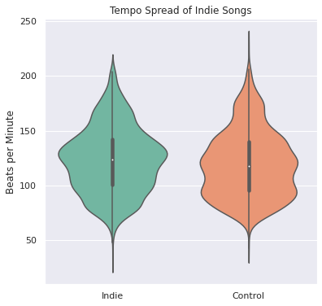

```python
seaborn.set(rc={'figure.figsize':(6,6)})
seaborn.violinplot(data=[indie_song_df.tempo, random_song_df.tempo], palette=seaborn.color_palette("Set2")[:2])
plt.title('Tempo Spread of Indie Songs')
plt.xlabel('')
plt.xticks(range(2), ['Indie', 'Control'])
plt.ylabel('Beats per Minute')
plt.show()
```

While the difference of mean is statistically significant, it is very hard to tell the difference between the two. Control generation seems to by chance have a bi-modal distribution, but other than that, the spread tempo isn't that interesting.

The reason why duration and tempo are analyzed and visuallized first separately is that they possess distinct and important y-axis. The audio features analyzed by Spotify, such as danceability, energy, and valence, on the other hand, are all values from 0 to 1, meaning they share the sam axis and can be plotted side by side.

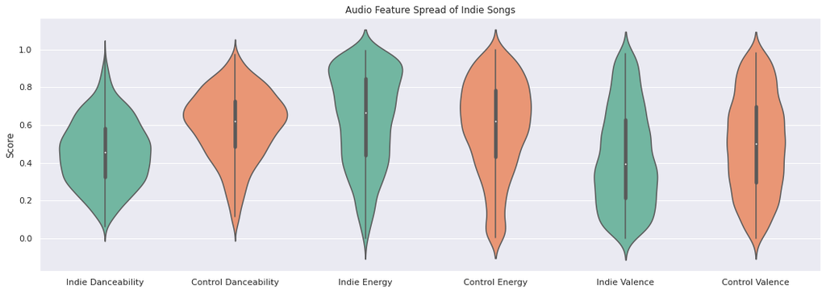

```python
seaborn.set(rc={'figure.figsize':(18,6)})
#Limit the color palette to two so indie and control maintains their different color.
seaborn.violinplot(data=[indie_song_df.danceability, random_song_df.danceability, indie_song_df.energy, random_song_df.energy,
                         indie_song_df.valence, random_song_df.valence], palette=seaborn.color_palette("Set2")[:2])
plt.title('Audio Feature Spread of Indie Songs')
plt.xlabel('')
plt.xticks(range(6), ['Indie Danceability', 'Control Danceability','Indie Energy', 'Control Energy', 'Indie Valence',
                      'Control Valence'])
plt.ylabel('Score')
plt.show()
```

The graph confirms our earlier suspicious that danceability--or specifically, the lacking of--is a critical characterstics where indie music truly differ itself from average music on a sonic level. Interestingly, indie danceability skews rights while control danceability skews left, which seems to suggest that all music still are ultimately spread out across the entire spectrum but differ in where they gather the most. We also can observe indie music having higher energy than average, counter to my hypothesis, and that indie music having lower valence or more negativity than average.

## Types of Indie

We have analyzed ways in which indie music can be defined away from music broadly, but the indieheads essentials list can also give us insight into diversity within the indie cannon. To do this, I grouped my song data by album and found the average of all their audio features.

```python
indie_song_df["year"] = pd.to_numeric(indie_song_df["year"])
album_features = indie_song_df.groupby(["album"], as_index=False).mean()
```

I found out that some of the albums names that have "(rematered)" or "xxth anniversary edition" etc. in the name, so I'll cut them out so the data will be cleaner.

```python
album_features["album"] = album_features["album"].str.split('(').str[0]
```

I've decided to plot the albums on a scatter plot by their track average audio features. I've decided on the axises of danceability and energy because I believe these can be two factors that could determine the average indie fan, such as myself, in prefering one album over another. Moreoever, danceability is already what we have established as determining how "indie" a piece of music sounds, plotting indie albums themselves on it will be interesting in seeing what bands can be seen as "more indie" as well.

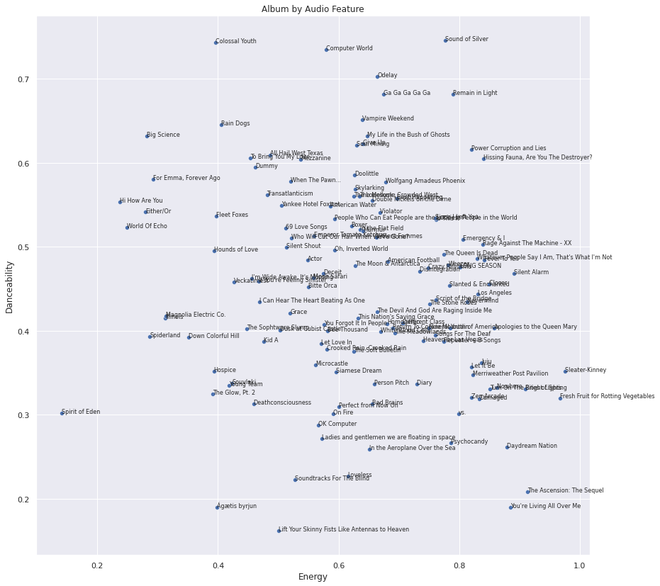

```python
seaborn.set(rc={'figure.figsize':(14,14)})
g = seaborn.scatterplot(data=album_features, x="energy", y="danceability", palette=seaborn.color_palette("Set2"))
plt.title('Album by Audio Feature')
plt.xlabel('Energy')
plt.ylabel('Danceability')

def label_point(x, y, val, ax):
    a = pd.concat({'x': x, 'y': y, 'val': val}, axis=1)
    for i, point in a.iterrows():
        ax.text(point['x'], point['y'], str(point['val']), fontsize=8)

label_point(album_features.energy, album_features.danceability, album_features.album, plt.gca())

g.get_figure().savefig("Indie Compass.png")
plt.show()
```

I believe this scatter plot would be especially of interest for those who are already fan of indie music, but I could also break down some example points from each of the four quadrants here to illustrate its helpfulness.

Sound of Silver by LCD Soundsystem is a dance-punk album using a wide array of instruments to arrange upbeat and rhythmic tracks, so it makes sense why it would be so far up-right as it certainly is the type of music people would dance to energetically.

For Emma, Forever Ago by Bon Iver is a mellow indie folk album that's certainly atmospheric and beautiful enough to invite people to dance slowly and elegantly to it.

Hospice by The Antlers is one of my favorite albums of all time about a devastating story of how sickness and abuse both physically and mentally drains a couple, definitely not music people would dance to.

Psychocandy by The Jesus and Mary Cain is an influential noise pop album, that certainly is energetic and loud, but not something people would move their body to.

```python
X1 = sm.add_constant(album_features["year"])
dnc_reg = sm.OLS(album_features["danceability"], X1).fit()
dur_reg = sm.OLS(album_features["duration"], X1).fit()
eng_reg = sm.OLS(album_features["energy"], X1).fit()
aco_reg = sm.OLS(album_features["acousticness"], X1).fit()
inst_reg = sm.OLS(album_features["instrumentalness"], X1).fit()
val_reg = sm.OLS(album_features["valence"], X1).fit()
tem_reg = sm.OLS(album_features["tempo"], X1).fit()
```

```python
print("dnc r squared:",dnc_reg.rsquared)
print("dur r squared:",dur_reg.rsquared)
print("eng r squared:",eng_reg.rsquared)
print("aco r squared:",aco_reg.rsquared)
print("inst r squared:",inst_reg.rsquared)
print("val r squared:",val_reg.rsquared)
print("tem r squared:",tem_reg.rsquared)
```

```
dnc r squared: 0.0006966345988516087
dur r squared: 0.003912828386573253
eng r squared: 0.024520565508743042
aco r squared: 0.024562431131555984
inst r squared: 0.0027719642796650845
val r squared: 0.030370143337756117
tem r squared: 0.002367670206678052
```

After graphing the albums by their audio features, I decided to try and see if there are tendencies and relations of how they have sonically changed over the years. However, as seen above, linear regression model demonstrates that there is no relation between any of the audio feature with time. However, I think the conclusion shouldn't be that indie hasn't changed its sound over the years, but more so that it demosntrates once again that Spotify's audio feature analysis isn't sufficient incapturing the whole of a piece of a music and misses certain factors.

Finally, I would like to investigate the relations between artists featured on the indieheads essentials list by creating a map of their connections through Spotify's related artist or "Fans also like" page.

```python
artists = dict(zip(indie_song_df.artist_uri.unique(),indie_song_df.artist.unique()))
```

```python
all_related_artists = {}
edges = []
```

```python
for artist_uri in artists.keys():
    related_artists = []
    if artist_uri in all_related_artists.keys():
        related_artists = all_related_artists[artist_uri]
    else:
        related_artists = [d["uri"] for d in sp.artist_related_artists(artist_uri)["artists"]]
        all_related_artists[artist_uri] = related_artists
    for a1 in related_artists:
        d_related_artists = []
        if a1 in artists.keys():
            edges.append((artists[a1], artists[artist_uri]))
        """
        if a1 in all_related_artists.keys():
            d_related_artists =  all_related_artists[a1]
        else:
            d_related_artists = [d["uri"] for d in sp.artist_related_artists(a1)["artists"]]
            all_related_artists[artist_uri] = d_related_artists
        for a2 in d_related_artists:
            if a2 in artists.keys():
                edges.append((artists[a2], artists[artist_uri]))
        """
```

```python
images = {}
sizes = {}
for uri in artists.keys():
    a = sp.artist(uri)
    if len(a["images"]) > 0:
        images[a["name"]] = a["images"][0]
    sizes[a["name"]] = a["popularity"]
```

```python
graph = nx.Graph()
graph.add_edges_from(edges)
g = Network(height="100%", width="100%", notebook=False)
g.inherit_edge_colors(True)
nodes = [i[0] for i in sorted(dict(graph.degree).items())]
g.barnes_hut()

for idx,i in enumerate(nodes):
    if i in images:
        g.add_node(i, value=sizes[i], label=i, title=i, shape='circularImage', image = images[i]["url"])
    else:
        g.add_node(i, value=sizes[i], label=i, title=i, shape='diamond')

g.add_edges(graph.edges)
```

```python
g.set_options('''
var options = {
  "nodes": {
    "shape": "diamond",
    "shadow": {
      "enabled": true
    },
    "size": 200
  },
  "color": {
      "highlight": {
        "border": "rgba(233,33,28,1)",
        "background": "rgba(255,94,100,1)"
      }
    },
  "edges": {
    "color": {
      "highlight": "rgba(216,83,84,1)",
      "inherit": true,
      "opacity": 0.25
    },
    "shadow": {
      "enabled": true
    },
    "smooth": {
      "type": "continuous",
      "forceDirection": "none"
    }
  },
  "physics": {
    "forceAtlas2Based": {
      "springLength": 100
    },
    "minVelocity": 0.75,
    "solver": "forceAtlas2Based"
  }
}
''')
g.show('network.html')
```

[output not shown]

## Conclusion

From this data exploration, we've found that indie music tend to be very rock-oriented genre-wise, with alternative rock in particular. Moreover, indie music are more likely to feature vocalless tracks, tend to be less danceable, less positive, but more energetic compared to the average music. Nevertheless, indie music is still very diverse, spanning across all sort of sounds and style.